# Entrega P4

# **Tema de trabajo**

Análisis de la cantidad de contaminantes del aire en el distrito de San Borja a lo largo de abril del 2016 y sus impactos en la salud.

# **Importancia**

La importancia del estudio reside en el análisis acerca de la cantidad de contaminantes en San Borja a lo largo del tiempo y relacionar los resultados con los efectos de contaminantes en el aire en la salud.

# **Objetivos**

**Objetivos Generales**

1. Relacionar la concentración de contaminantes en el aire con sus efectos directos en la salud.

**Objetivos Específicos**

1. Dar un análisis de qué tan relacionados están estos contaminantes y determinar el patrón de estos gráficos para el mes siguiente.
2. Relacionar el contaminante con más concentración en el aire con las enfermedades específicas que puede causar
3. Indicar un análisis de capacidad de la mala gestión del organismo local estableciendo argumentos en base a nuestro resultado

# **Variables**

**Variables Numéricas** **Cuantitativas Continua**

1. **PM10**: Es la concentración de partículas en suspensión con un tamaño igual o inferior a 10 micras en microgramos por metro cúbico.
2. **PM 2.5**: Es la concentración de partículas en suspensión con un tamaño igual o inferior a 2.5 micras en microgramos por metro cúbico.
3. **SO2**: Concentración de partículas de dióxido de azufre en el aire en microgramos por metro cúbico.
4. **NO2**: Concentración de partículas de dióxido de nitrógeno en el aire en microgramos por metro cúbico.
5. **O3**: Concentración de partículas de dióxido de ozono en el aire en microgramos por metro cúbico.
6. **CO**: Concentración de partículas de monóxido de carbono en el aire en microgramos por metro cúbico.

**Variables Categóricas** **Categóricas Ordinales**

1. **Mes**: Toma en consideración un registro de 12 meses.
2. **Año**: Es el registro anual que se tiene desde 2010 hasta 2020.
3. **Día**: Se realizó un registro máximo de 31 días.
4. **Hora**: Toma en consideración la hora hasta un máximo de 23.

**Categóricas Cardinales**

1. **Código Estación**: Indica la clasificación por estación de un distrito de Lima.
2. **Estación**: Es el lugar donde se toma como referencia de punto para cada distrito.

# **Limpieza de base de datos**

**Criterios de Limpieza**

La base de datos inicial extraída del SENAMHI contaba con un total de 700000 observaciones de distintos distritos, de la cual se extrajo la información del distrito de San Borja. Al introducir la base de datos a R con la función read_csv(), observamos que R no leía correctamente los datos al dejar datos como N.A a pesar de que estos dentro del csv estaban completos. Para solucionar este problema, se decidió en un principio completar manualmente la base de datos de San Borja, tomando como referencia para la primera entrega 912 observaciones completadas por el grupo de forma manual. Pero al final, se pudo filtrar la base de datos estableciendo el tipo de variables en la entrada de la lectura de R debido a que R no reconocía el tipo de variables para SO2,NO2 y O3 para ello se consideró el siguiente código:

```r
y<-read_csv("datos_horarios_contaminacion_lima.csv", col_types = cols(.default = col_double(), ESTACION  = col_character(),`CODIGO ESTACION` =  col_character()))
```

Se consideró únicamente al distrito de San Borja en el año 2016 en el mes de Abril debido a la cantidad de datos con los que contaba (observaciones completas), mientras que los otros distintos no tenían datos de PM2,5 y CO principalmente, San Borja si contaba con estas variables. Siendo estas dos variables de importancia para poder determinar si los niveles de contaminantes en el aire de acuerdo a la ECA-aire son dañinos para la salud de las personas.

**Población**

Los contaminantes del aire en el distrito de San Borja

**Muestra**

Los contaminantes del aire en el distrito de San Borja a lo largo de abril del 2016

**Tipo de muestreo**

En este caso estamos utilizando un muestreo por conveniencia debido a que estamos seleccionando unos datos ordenados en vez de datos al azar.

# **Descriptores Numéricos**

1. **PM10**:
1. Covarianza: este descriptor será utilizado para obtener la información sobre la relación de datos entre PM10 y PM2.5. Si este valor es positivo nos brindará información de que a valores altos de PM10 hay una mayor tendencia a encontrar valores altos de PM2.5 y a valores bajos de PM10, correspondientemente valores bajos.
2. Media: este descriptor será utilizado para reconocer si el promedio de PM10 por horas es superior o inferior según los Estándares Nacionales de Calidad Ambiental del Aire (ECA del aire).
3. Desviación estándar: este descriptor será utilizado para poder determinar la variación existente entre los datos de la variable PM10 y su media, para así poder observar si de acuerdo con el tiempo estos tienen una dependencia a variar en mayor o menor medida de acuerdo a la estación del año.
4. Cuartiles: este descriptor será utilizado para saber qué tanto es la concentración de datos contaminantes tomado por rangos y también establecer los rangos de las horas con más concentración de contaminantes.
2. **PM2.5**:
1. Covarianza: este descriptor será utilizado para obtener la información sobre la relación de datos entre PM2.5 y PM10. Si este valor es positivo nos brindará información de que a valores altos de PM2.5 hay una mayor tendencia a encontrar valores altos de PM10 y a valores bajos de PM2.5, correspondientemente valores bajos
2. Media: este descriptor será utilizado para reconocer si el promedio de PM2.5 por horas es superior o inferior según los Estándares Nacionales de Calidad Ambiental del Aire (ECA del aire).
3. Desviación estándar: este descriptor será utilizado para poder determinar la variación existente entre los datos de la variable PM2.5 y su media, para así poder observar si de acuerdo con el tiempo estos tienen una dependencia a variar en mayor o menor medida de acuerdo a la estación del año.
4. Cuartiles: este descriptor será utilizado para saber qué tanto es la concentración de datos contaminantes tomado por rangos y también establecer los rangos de las horas con más concentración de contaminantes.
3. **SO2**:
1. Covarianza: este descriptor será utilizado para poder visualizar la dispersión de datos de la cantidad de partículas de dióxido de azufre en el aire en microgramos por metro cúbico.
2. Media: este descriptor será utilizado para reconocer si el promedio de la cantidad de partículas de dióxido de azufre en el aire en microgramos por metro cúbico por horas es superior o inferior según el Índice Nacional de Calidad del Aire (ICA).
3. Varianza: este descriptor será utilizado para el empleo de los datos de la cantidad de partículas de dióxido de azufre en el aire en microgramos por metro cúbico para ver que tan próximos están estos datos a su promedio y observar qué tanto influye los valores atípicos.
4. Cuartiles: este descriptor será utilizado para saber qué tanto es la concentración del SO2 tomado por rangos y ver el patrón que siguen dependiendo cuando se toma los datos completos a cuando se toma por partes.
4. **NO2**:
1. Covarianza: este descriptor será utilizado para poder visualizar la dispersión de datos de la cantidad de partículas de dióxido de nitrógeno en el aire en microgramos por metro cúbico.
2. Media: este descriptor será utilizado para reconocer si el promedio de la cantidad de partículas de dióxido de nitrógeno en el aire en microgramos por metro cúbico por horas es superior o inferior según el Índice Nacional de Calidad del Aire (ICA).
3. Varianza: este descriptor será utilizado para el empleo de los datos de la cantidad de partículas de dióxido de nitrógeno en el aire en microgramos por metro cúbico para ver que tan próximos están estos datos a su promedio y observar qué tanto influye los valores atípicos.
4. Cuartiles: este descriptor será utilizado para saber qué tanto es la concentración del NO2 tomado por rangos y ver el patrón que siguen dependiendo cuando se toma los datos completos a cuando se toma por partes.
5. **O3**:
1. Correlación lineal: este descriptor será utilizado para poder visualizar la dispersión de datos de la cantidad de partículas de dióxido de ozono en el aire en microgramos por metro cúbico.
2. Media: este descriptor será utilizado para reconocer si el promedio de la cantidad de partículas de dióxido de ozono en el aire en microgramos por metro cúbico por horas es superior o inferior según el Índice Nacional de Calidad del Aire (ICA).
3. Varianza: este descriptor será utilizado para el empleo de los datos de la cantidad de partículas de dióxido de ozono en el aire en microgramos por metro cúbico para ver que tan próximos están estos datos a su promedio y observar qué tanto influye los valores atípicos.
4. Cuartiles: este descriptor será utilizado para saber qué tanto es la concentración del O3 tomado por rangos y ver el patrón que siguen dependiendo cuando se toma los datos completos a cuando se toma por partes.
6. **CO**:
1. Correlación lineal: este descriptor será utilizado para poder visualizar la dispersión de datos de la cantidad de partículas de monóxido de carbono en el aire en microgramos por metro cúbico.
2. Media: este descriptor será utilizado para reconocer si el promedio de la cantidad de partículas de monóxido de carbono en el aire en microgramos por metro cúbico por horas es superior o inferior según el Índice Nacional de Calidad del Aire (ICA).
3. Varianza: este descriptor será utilizado para el empleo de los datos de la cantidad de partículas de monóxido de carbono en el aire en microgramos por metro cúbico para ver que tan próximos están estos datos a su promedio y observar qué tanto influye los valores atípicos.
4. Cuartiles: este descriptor será utilizado para saber qué tanto es la concentración del CO tomado por rangos y ver el patrón que siguen dependiendo cuando se toma los datos completos a cuando se toma por partes.

# **Descriptores Gráficos**

**Boxplot:** El boxplot será de utilidad para poder comparar las distribuciones de datos según los cuartiles de la variable analizada en el gráfico.

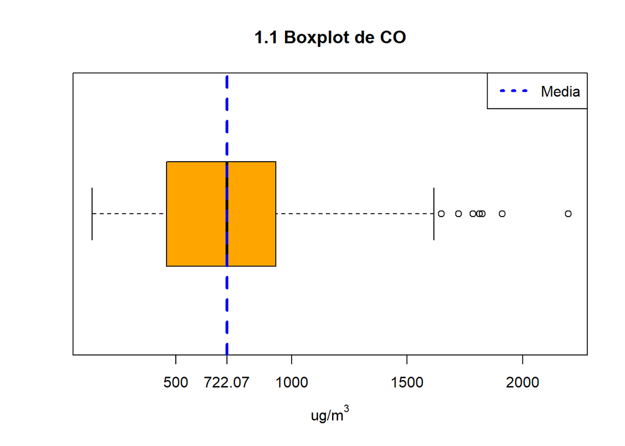

En este caso nos damos cuenta que hay una mayor cantidad de CO que se encuentran en un rango de 500 a 1000$ug/m^3$, esto es debido a que en todo momento hay circulación de vehículos alrededor del distrito por lo que en ningún momento el valor de este contaminante será igual a cero, mientras que el máximo valor se habría de registrar en una hora de gran concurrencia vehicular . Asimismo, se muestran datos que se podrían considerar atípicos pero en realidad aun así se trabajaran con los mismos , ya que trabajamos con sensores calibrados y cada dato fue registrado y si es atípico es debido a un factor externo.

**Gráfico de barras:** El gráfico de barras será de utilidad para poder determinar si a medida del paso de los años la cantidad de contaminantes tiene una tendencia al aumento o disminución.

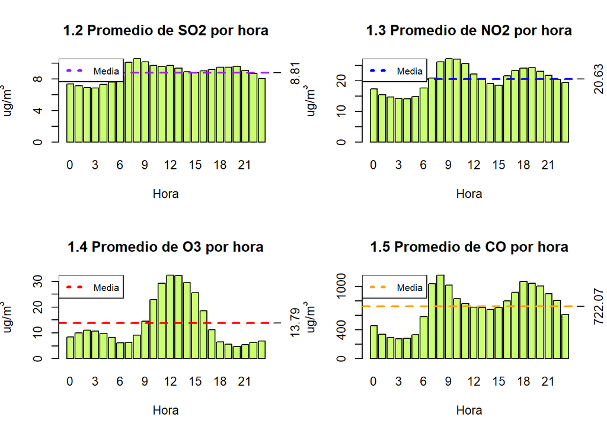

Como podemos observar en el gráfico 1.5, los picos de la concentración de CO suceden en los rangos 7-9 y 18-20, esto puede ser debido a las conocidas “Horas Punta” en las cuales la cantidad de autos que liberan estos contaminantes aumenta de manera exponencial, produciendo estos picos en el gráfico. Mientras que los valles dentro del gráfico que suceden en la madrugada en el rango de 2-4 suceden al igual que los picos por la cantidad de carros que se conducen en el área, al ser un área poco concurrida por los conductores la cantidad de partículas es considerablemente menor.

Observamos además que esta tendencia también se ve reflejada en los gráficos de SO2 y NO2, mientras que en el gráfico del contaminante ozono no observamos la misma tendencia. Esto es debido a que principalmente la generación del contaminante es proporcional a la cantidad de calor y luz solar del ambiente, lo que se ve reflejado en el gráfico 1.4 donde observamos que las horas en las que hay más concentración del contaminante son entre las 10am y 5pm horas donde se acostumbra a tener grandes cantidades de luz solar.

**Histograma:** Nos permitirá observar claramente cómo varía la cantidad de distintos contaminantes de acuerdo a las fechas de las observaciones, mostrando así si existe una tendencia a variar dependiendo de las estaciones, temperatura, entre otros.

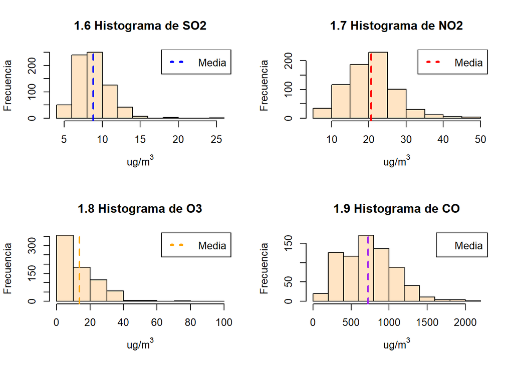

**Gráfico violín:**

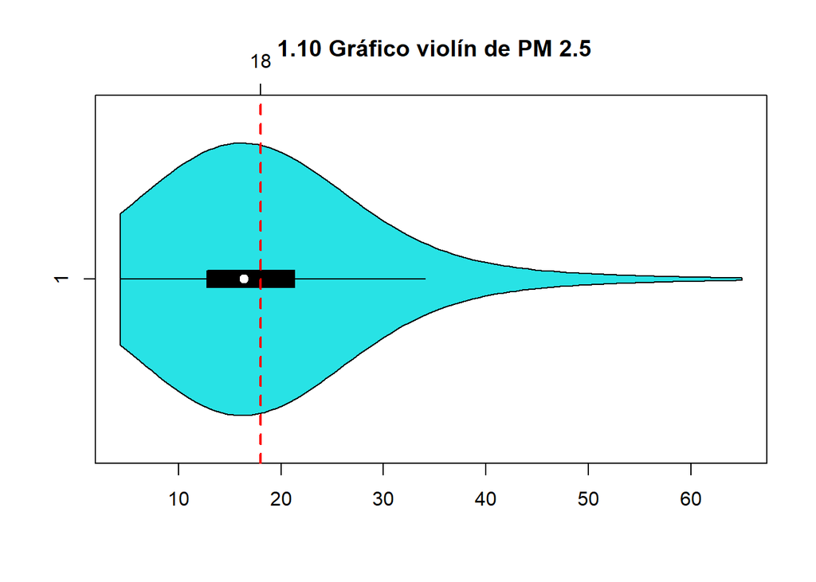

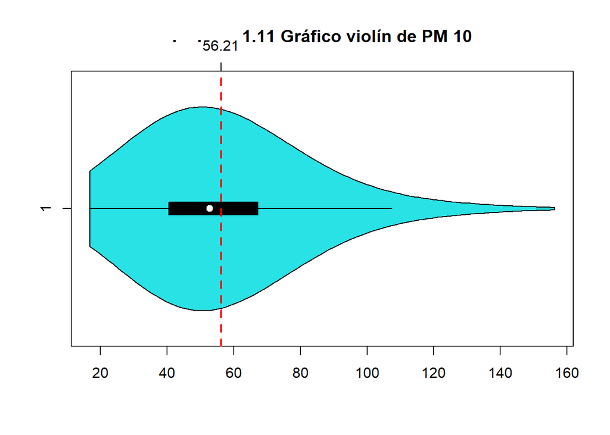

Como se observa en los gráficos de violín de las variables PM10 y PM2.5, podemos observar que la distribución de los datos es casi la misma solo que la cantidad de PM2,5 es menor a la cantidad de PM10. Este patrón es debido a que el valor de PM2,5 esta incluido dentro de la variable PM10, una parte de las partículas en suspensión menores a 10 micrómetros incluye a aquellas menores a 2,5 micrómetros por lo que al estar la variable PM2,5 dentro de la variable PM10 podemos observar que sus gráficos violines tienen una distribución muy parecida.

**Gráficos de Correlación:**

**Gráfico de dispersión:** Nos permite saber que tan dispersos están los datos gráficamente y también qué tan relacionadas están las variables, además nos permitirá observar si las variables tienen tendencias lo que nos permitiría hacer predicciones de acuerdo a la base de datos para determinar si en un futuro los contaminantes serán un problema más serio para la salud.

[figure not shown]

```
## [1] 0.6499582
```

Podemos observar en el gráfico 2 que la relación que tienen los contaminantes SO2 y NO2 es una correlación positiva fuerte, de acuerdo con el valor obtenido de la correlación de ambas variables (siendo 0.649). Podemos determinar que la relación existente entre los dos contaminantes es debido a que ambos son generados por la combustión de combustibles fósiles, y al ser causados ambos principalmente por el consumo de los vehículos en el distrito.

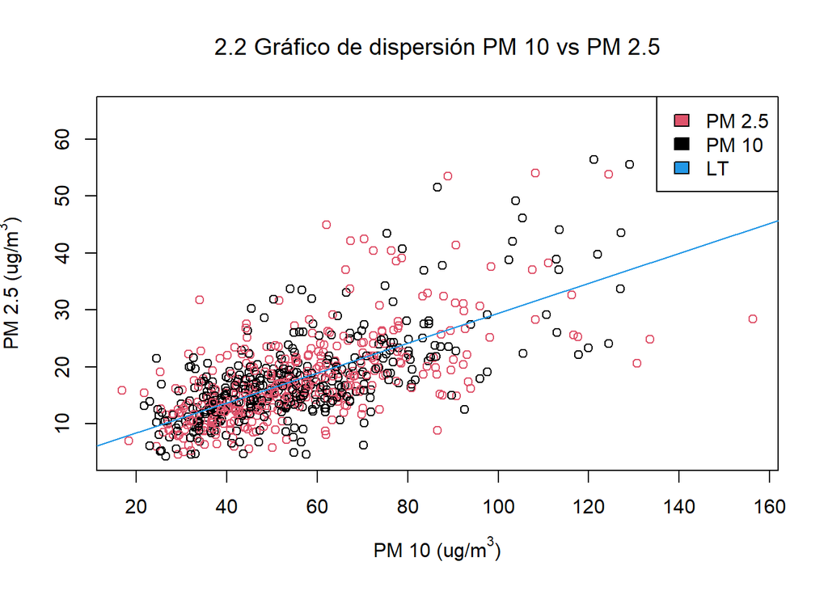

```
## [1] 0.6786329
```

En el gráfico 2.2 podemos observar como existe una relación entre las variables PM10 y PM2,5, afirmación que se ve sustentada con el valor de correlación obtenido (siendo: 0.679) lo que da una correlación positiva fuerte. Esta relación se puede ver explicada debido a que ambas variables representan la cantidad de partículas, pero cada una con un tamaño máximo distinto. Por lo tanto si PM10 representa las partículas menores a 10 micrómetros, y PM2,5 representa las partículas menores a 2,5 micrómetros, podemos afirmar que la variable PM2,5 estará dentro de la variable PM10. Definida matemáticamente como, PM(2,5) =PM(10)-PM(<2.5).

[figure not shown]

```
## [1] 0.7250297
```

Al igual que en la figura 2.1, en la figura 2.3 observamos que entre ambos compuestos contaminantes NO2 y CO están relacionados, de acuerdo con el valor de correlación entre variables (siendo: 0.725). Determinamos que entre ambas variables existe una correlación positiva fuerte debido a que la fuente que genera ambos contaminantes es el consumo y quema de combustibles fósiles como se observa en vehículos. Por lo tanto, ambas variables son dependientes de la cantidad de autos en circulación.

[figure not shown]

```
## [1] 0.6435051
```

En el gráfico 2.4 también podemos realizar el mismo análisis que en el 2.1 y 2.3. Determinando que existe una relación entre los contaminantes CO y SO2, teniendo un valor de correlación de 0.644 lo que significa una correlación positiva fuerte. Además, el motivo es el mismo expuesto en las gráficas previas, al ser ambos compuestos generados al reaccionar la quema de combustibles fósiles con el oxígeno del ambiente se generan ambos. Siendo ambos dependientes de la concurrencia vehicular dentro del distrito.

Cabe recalcar que se omitió en las gráficas de relaciones entre variables al contaminante O3 (Ozono), debido a que esta variable no presenta una relación directa a los demás contaminantes, al ser generado por otra fuente. Mientras que los contaminantes son principalmente generados por la combustión en vehículos, el ozono es generado por la radiación solar y el calor del ambiente por lo que se determinó que no se haría relación con la variable ozono.

# **Variables Aleatorias**

**Variables Aleatorias continua**

**PM10 y PM2.5**

Analizando de acuerdo al decreto supremo emitido por el MINAM, con respecto a contaminantes y su concentración en zonas pobladas podemos determinar cual es la probabilidad de que estos contaminantes superen los límites establecidos por el MINAM, siendo estos límites para PM10=100$ug/m^3$ y para PM2=50$ug/m^3$.

Sabemos que para esta variable contamos con 720 observaciones y que los resultados oscilan entre 16,79 y 156,3 (rango).

Para obtener la probabilidad de que la concentración de las partículas menores a 10 micrómetros o 2,5 micrómetros supere al límite establecido por el MINAM, debemos empezar calculando la media y la desviación típica a partir de las observaciones:

Para PM10:

1. Media:

```
## [1] 56.20553
```

2)Desviación estándar:

```
## [1] 21.64736
```

Para PM2,5:

1. Media:

```
## [1] 17.99583
```

2)Desviación estándar:

```
## [1] 8.376275
```

La variable PM10 puede aproximarse a una distribución normal de media 56,2 y desviación típica de 21,6, para poder determinar cual es la probabilidad de que este contaminante supere en concentración al límite establecido, se realiza un gráfico de densidad de la variable para cada una:

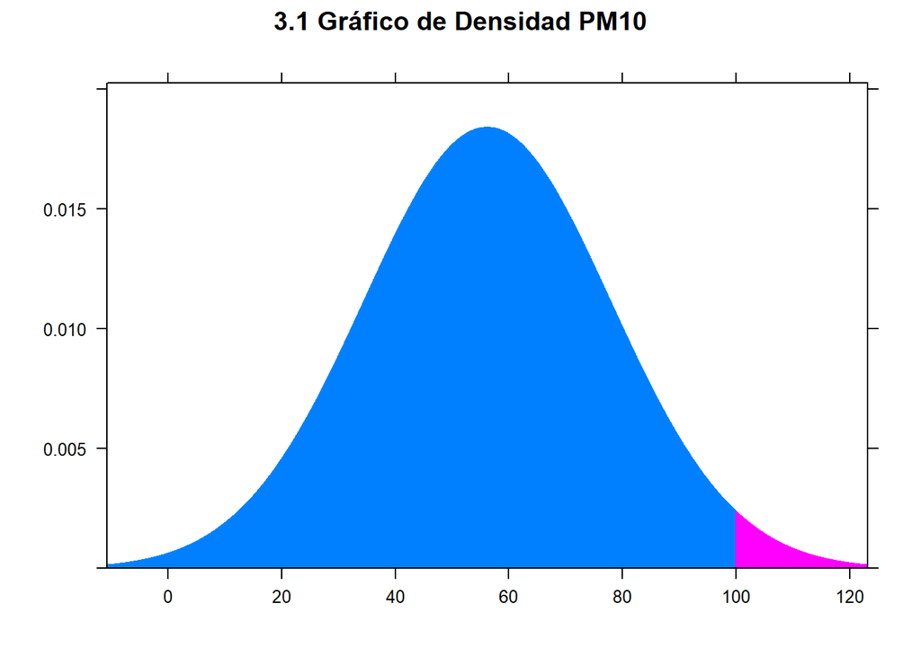

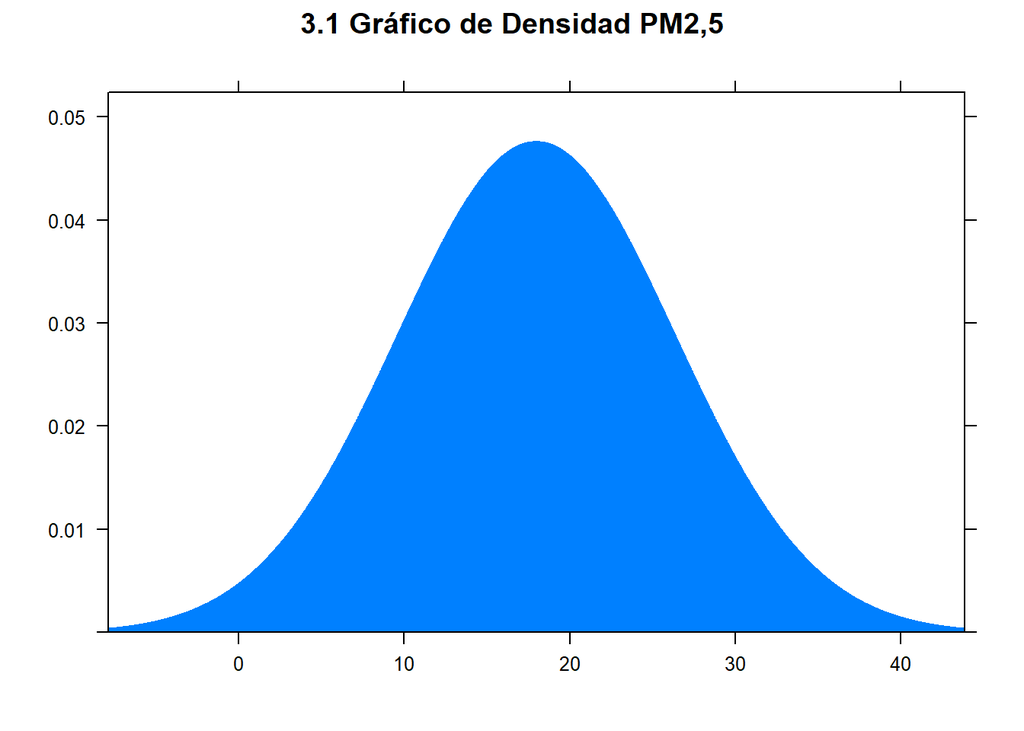

Se calculará la probabilidad de que los valores de ambos contaminantes superen al límite establecido por la ECA-aire:

```r
#Probabilidad 1
p1 = (1 - pnorm((100), mean(P$`PM 10`), sd= sd(P$`PM 10`)))
p1
```

```
## [1] 0.02153212
```

```r
#Probabilidad 2
p2 = (1 - pnorm( (50) , mean(P$`PM 2.5`),  sd(P$`PM 2.5`)))
p2
```

```
## [1] 6.65067e-05
```

Como observamos, la probabilidad de que supere al establecido por el MINAM los contaminantes son valores reducidos. El valor más considerable es el del contaminante PM10, pero al mismo tiempo no es tan nocivo para la salud como otros contaminantes en esos niveles de concentración. A pesar de esto, sería importante observar los impactos en la salud que tendrían estas concentraciones para las personas.

# **Intervalos de confianza**

## **SO2**

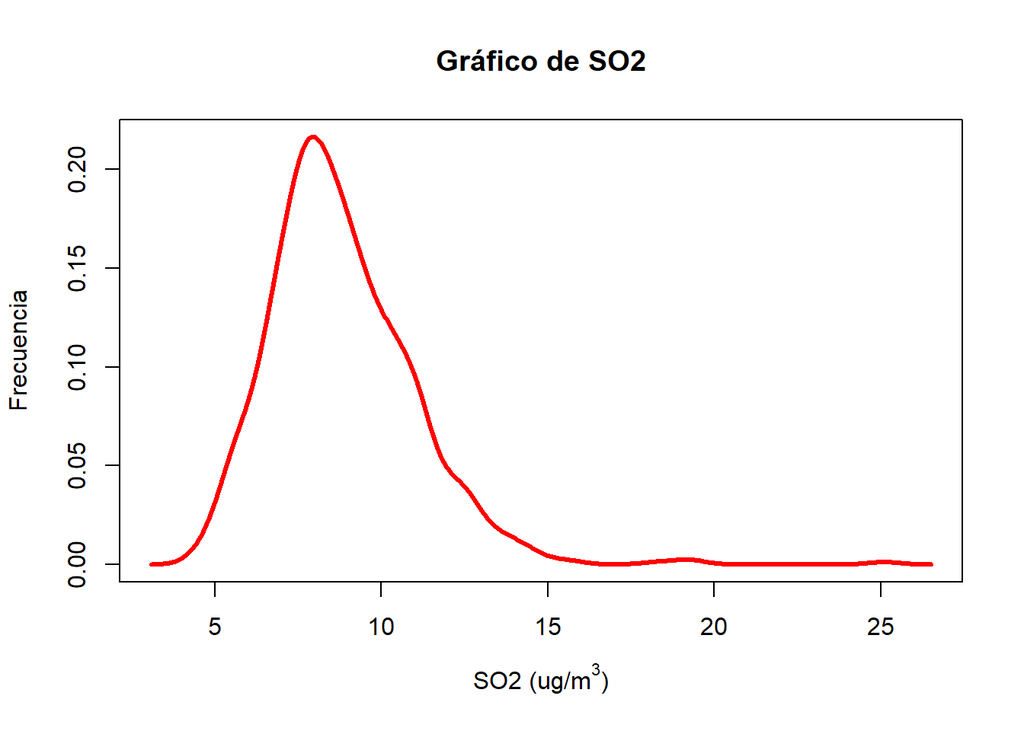

*Desviación estándar de SO2*

[output not shown]

Precisión: ± 0.05

Nivel de confianza: 95%

Tamaño de muestra ideal: 654

Priorizamos un nivel de confianza alto (95%) ya que no se observa una desviación estándar muy alta, por lo que la distribución de los datos no se aleja del intervalo de confianza de la muestra. Con una precisión elegida de ± 0.05 argumentado bajo el mismo criterio de una baja desviación estándar se puede hacer el cálculo de cuál sería el tamaño de la muestra ideal para la variable:

```
## [1] 654.5862
```

Intervalo de confianza:

```
## [1] 8.17863 9.43887
```

## **CO**

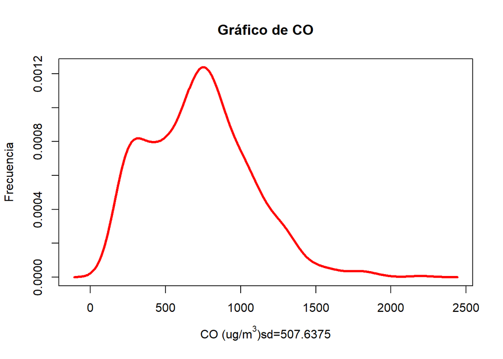

*Desviación estándar de CO*

```
## [1] 507.6375
```

Precisión: ±0.1

Nivel de confianza:85%

Tamaño de muestra ideal: 719

Se decidió ir un intervalo de confianza reducido ya que la mayoría de estos datos están dispersos y se encontró mejorar la precisión de estos para el intervalo de confianza. Además, se cuenta con una precisión de ±0.1 que busca aumentar la precisión para los resultados considerando una población con datos dispersos. En base a la alta desviación estándar de la variable se utiliza un nivel de confianza del 85%, utilizando este nivel de confianza podemos hacer el cálculo del tamaño de la muestra ideal para la variable:

```
## [1] 719.9946
```

Intervalo de confianza:

```
## [1] 694.8317 749.2994
```

Del resultado podemos observar que para poder tener resultados precisos el tamaño de la muestra que se debería utilizar es el tamaño completo de la población.

## **O3**

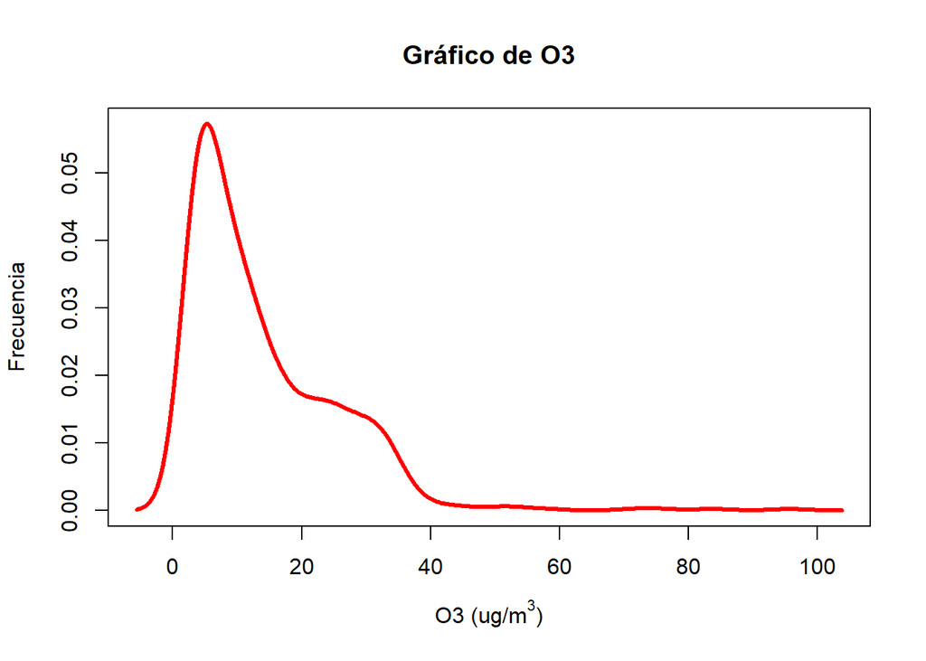

*Desviación estándar de O3*

```
## [1] 10.98273
```

Precisión: ±0.02

Nivel de confianza:99%

Tamaño de muestra ideal: 720

```
## [1] 719.9394
```

Intervalo de confianza:

```
## [1] 12.73779 14.84638
```

Del resultado obtenido podemos observar que el tamaño ideal de la muestra para poder tener la precisión requerida sería el tamaño de la población, siendo estas 720 observaciones.

## **NO2**

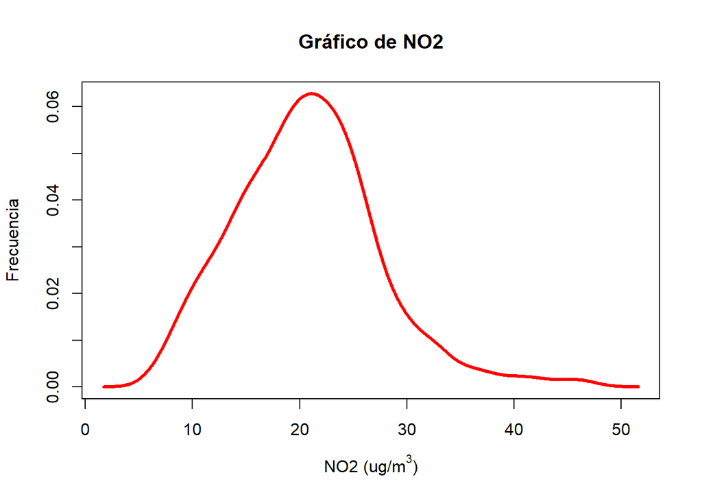

*Desviación estándar de NO2*

[output not shown]

Precisión: ± 0.05

Nivel de confianza: 95%

Tamaño de muestra ideal: 713

Se consideró un nivel de confianza relativamente alto, pero también conservando la precisión mínima para que el intervalo de confianza no se vea muy apretado en el cálculo del intervalo de confianza ya que presenta datos relativamente juntos sin una variación considerable. Considerando lo expuesto previamente el nivel de confianza se toma en 95%, y la precisión de ± 0.05 para poder incrementar la precisión de los cálculos a realizar. A partir de ambas premisas se puede hacer el cálculo del tamaño de la muestra ideal para la variable:

```
## [1] 712.6951
```

Intervalo de confianza:

```
## [1] 19.74978 21.50828
```

Del resultado podemos observar que el tamaño de muestra ideal para la variable es 713 observaciones, basándonos en el nivel de confianza y las precisiones requeridas.

## **PM2,5**

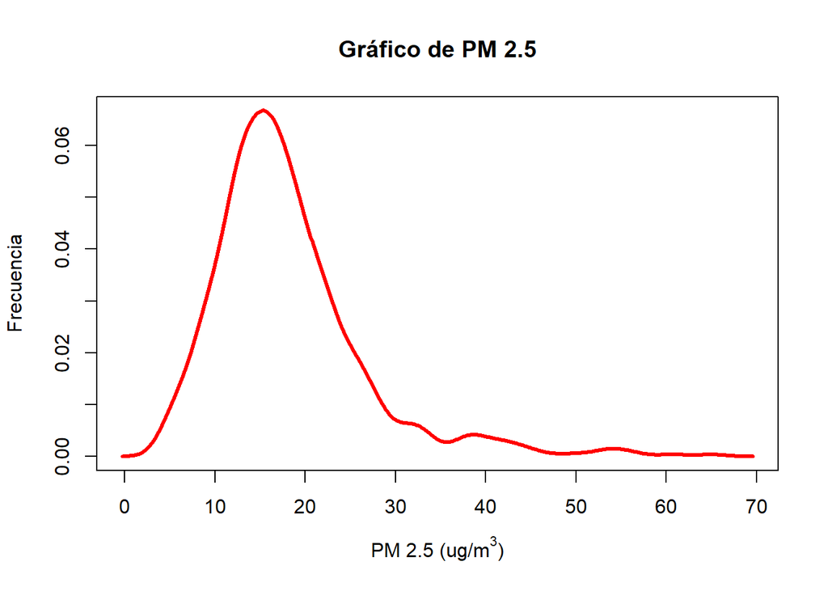

*Desviación estándar de PM 2.5*

```
## [1] 9.349944
```

Precisión: ± 0.05

Nivel de confianza: 95%

Tamaño de muestra ideal: 715

La gráfica presenta una distribución parecida a normal por lo que asumimos un nivel de confianza y precisión estándar debido a que la desviación no es tan alta por lo que decidió por intervalo de confianza estándar que entre la precisión y el nivel de confianza. Al observar una distribución de datos no tan dispersa podemos asumir un nivel de confianza de (95%) y una precisión de ± 0.05 basándonos en la desviación estándar de la variable, a partir de esto podemos calcular el tamaño de la muestra ideal para la variable:

```
## [1] 715.2302
```

Intervalo de confianza:

```
## [1] 17.31288 18.67879
```

# **Pruebas de hipótesis**

**Hipótesis 1**

En vista que San borja es un distrito donde la cantidad de contaminantes es muy notorio a horas de la tarde.Se sospecha que a partir del mediodía para adelante es donde se encuentra mayor concentración de contaminantes.En este caso se recurrió a un nivel de confianza de 99% ya que como la variable es hora la dispersión de los datos es siempre la misma.

Prueba de hipótesis unilateral (cola a la izquierda)

H0: u ≥ 12 h

Hp: u < 12 h

```r
µ = 12
σ = sd(L2$HORA)
n = length(P$HORA)
media.muestral = mean(P$HORA)
α = 0.01
z <- (media.muestral-µ)*sqrt(n)/σ
z
```

```
## [1] -1.936677
```

```r
i=qnorm(α,0,1)
i
```

```
## [1] -2.326348
```

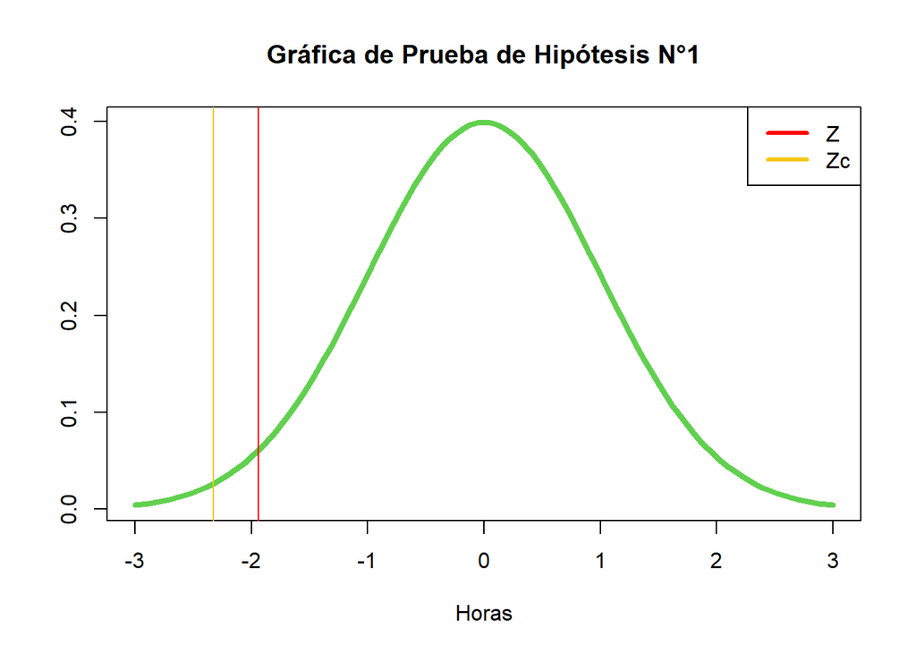

$$Z_c < Z$$

**Hipótesis 2**

El contaminante SO2, puede llegar a ser dañino para la salud humana a partir de 300$ug/m^3$, por lo que decidimos plantear una hipótesis para saber si la media poblacional es igual o sobrepasa el límite establecido de 300$ug/m^3$. Se usa un nivel de confianza de 95%, ya que ya fue explicado en la primera parte de la entrega. En este caso la hipótesis nula será (H0: u≥300) y la hipótesis alterna (H1: u< 300) .

Prueba de hipótesis unilateral (cola a la izquierda)

H0: u≥ 300 $ug/m^3$ Hp: u< 300 $ug/m^3$

```r
µ = 300
σ= sd(L2$SO2)
n = 720
media.muestral=mean(P$SO2)  #muestral
α = 0.05
Z <- (media.muestral-µ)*sqrt(n)/σ
Z
```

```
## [1] -905.7388
```

```r
Pc=qnorm(0.05,0,1)
Pc
```

```
## [1] -1.644854
```

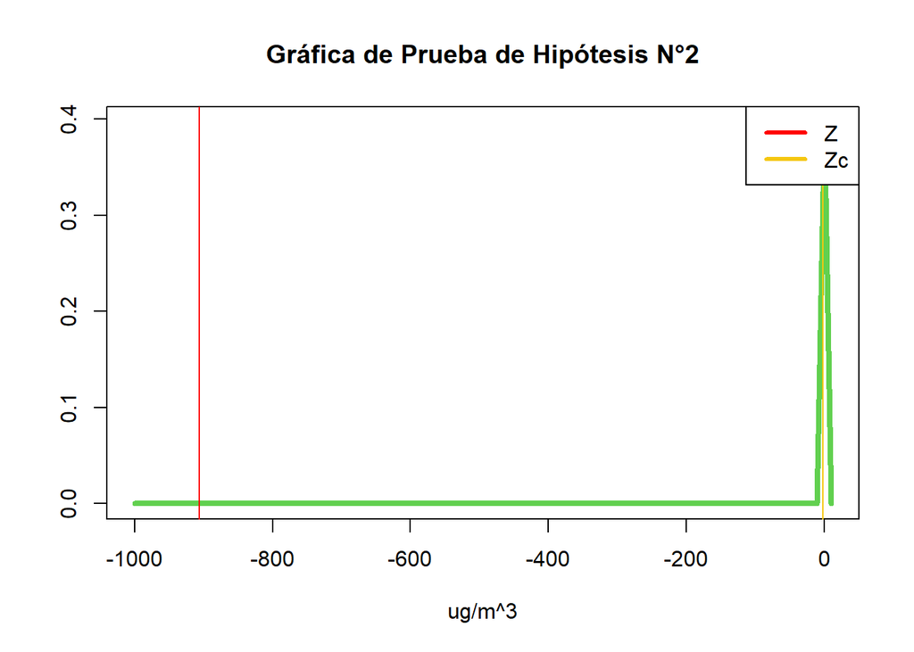

$$Z= -905.7388$$
$$P_c= -1.644854$$

La hipótesis se rechaza, ya que el Z es menor que el punto crítico se encuentra en el área de rechazo. Podemos concluir que la media poblacional de SO2, no sobrepasa los límites para la salud.

**Hipótesis 3**

Para la prueba de hipótesis 3 , queríamos descartar la sospecha de que la media poblacional del contaminante PM2,5, se encuentre en una cantidad nociva para la salud humana. Por lo que decidimos plantear una hipótesis para saber si la media poblacional es igual o sobrepasa el límite establecido de 50$ug/m^3$ por MINAM. En este caso la hipótesis nula será (H0: u≥50) y la hipótesis alterna (H1: u<50) . Se usa un nivel de confianza de 95%, ya que ya fue explicado en la primera parte de la entrega.

Prueba de hipótesis unilateral (cola a la izquierda)

```r
µ = 50
σ = sd(L2$`PM 2.5`)
n = 720
media.muestral = mean(P$`PM 2.5`)
α = 0.05
Pc<-qnorm(α,0,1)
Pc
```

```
## [1] -1.644854
```

```r
Z <- (media.muestral-µ)*sqrt(n)/σ
Z
```

```
## [1] -91.84674
```

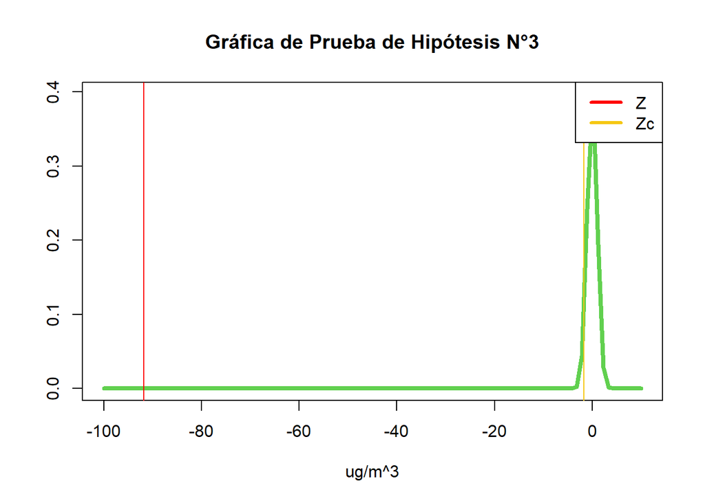

$$Z= -91.84674$$
$$P_c=-1.644854$$

La hipótesis nula se rechaza, ya que nuestro Z es menor que el punto crítico y se encuentra en el área de rechazo.

# **Regresión Lineal Simple**

Variable X (independiente): Las horas por cada día elegido en el mes.

Variable Y (dependiente): variables cuantitativas PM10, PM2.5 y SO2.

**Supuestos:**

- En cuanto a nuestra segunda prueba de hipótesis, el grupo supone que el contaminante SO2 no pasará el límite de 300$ug/m^3$ en todos los días a las 19:00 horas (hora punta) en la ciudad.
- El día 30 del mes tendrá una pendiente en la ecuación de la regresión lineal simple mayor con respecto al día 1 debido a la acumulación de gases contaminantes después de haber pasado 29 días entre estos.
- La variable X y Y tendrá una relación directa debido a que a medida que aumenten las horas en el día habrá más cantidad de gases contaminantes debido a la acumulación de estos. -Analizar si nuestro modelo es funcional gracias a la tercera prueba de hipótesis, donde se evaluó si la media poblacional de PM2.5 no sobrepasa el límite establecido por el MINAM de 50$ug/m^3$.

**Para la variable SO2**

Se crea la nueva base de datos para las 19:00 horas de cada día.

Se emplea el cálculo y representación de la recta de mínimos cuadrados:

Análisis:

```
##
## Call:
## lm(formula = siete$SO2 ~ siete$DIA, data = siete)
##
## Residuals:
##     Min      1Q  Median      3Q     Max
## -2.1477 -0.7155  0.1372  0.7197  2.5288
##
## Coefficients:
##             Estimate Std. Error t value Pr(>|t|)
## (Intercept)  7.08598    0.42803  16.555 5.41e-16 ***
## siete$DIA    0.15617    0.02411   6.477 5.11e-07 ***
## ---
## Signif. codes:  0 '***' 0.001 '**' 0.01 '*' 0.05 '.' 0.1 ' ' 1
##
## Residual standard error: 1.143 on 28 degrees of freedom
## Multiple R-squared:  0.5998, Adjusted R-squared:  0.5855
## F-statistic: 41.96 on 1 and 28 DF,  p-value: 5.115e-07
```

Los errores típicos de los estimadores de los parámetros β0 y β1 son: 0.42803 y 0.02411.

El estimador de la desviación típica de los errores σ aparece como Residual standard error y su valor es 1.143

El
$$r^2 = 0.5855$$

Para la variable SO2, se plantea lo siguiente: *H0:β0=0 y H0:β1=0* teniendo en cuenta los cocientes entre el estimador y su error típico son: para el intercepto 16.555 y 6.477 para la pendiente. Los correspondientes p-valores: 5.41e-16 y 5.11e-07 son muy pequeños por lo que se rechazan ambas hipótesis para los niveles de significación habituales.

Los intervalos de confianza para los parámetros son los siguientes con un nivel de confianza del 95%:

```
##                 2.5 %    97.5 %
## (Intercept) 6.2091986 7.9627554
## siete$DIA   0.1067857 0.2055613
```

Los parámetros de la ecuación de la recta de mínimos cuadrados que relaciona el día en las 19:00 horas correspondiente en función de la variable SO2, vienen dados por la columna ´Estimate´ de la tabla ´Coefficients´ de la salida anterior. Por lo tanto, en este ejemplo la ecuación de la recta de mínimos cuadrados es:

$$SO2(t)=7.08598+0.15617t$$
Donde el dominio y rango de las ecuaciones es:

$D =$ $t$ $ϵ$ $[0;30]$

$R =$ $SO2$ $ϵ$ $[6.5;14.3]$

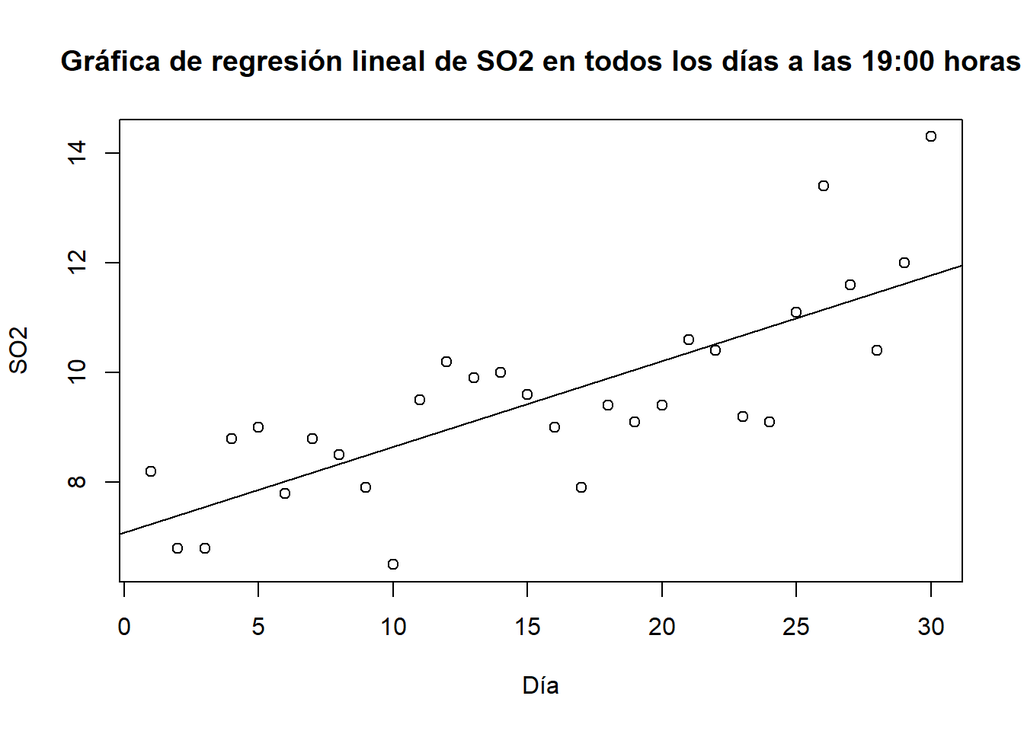

El coeficiente de determinación (es decir, el coeficiente de correlación al cuadrado) mide la bondad del ajuste de la recta a los datos. A partir de la salida anterior, vemos que su valor en este caso es Multiple R-squared: 0.5998.

Para la variable SO2, se puede asegurar que no sobrepasa el límite de los 300$ug/m^3$, gracias a esto se puede decir que se trata de un modelo funcional ya que presenta un coeficiente de determinación alto para tratarse de una regresión lineal. Se puede ver una pendiente positiva y esto puede deberse a la acumulación de gases contaminantes en el aire a medida que pasan los días y no sería beneficioso para el análisis.

**Para la variable PM10:**

Se crean las nuevas bases de datos para el primer y trigésimo día.

Se emplea el cálculo y representación de la recta de mínimos cuadrados:

Análisis día 1:

```
##
## Call:
## lm(formula = dia1$`PM 10` ~ dia1$HORA, data = dia1)
##
## Residuals:
##     Min      1Q  Median      3Q     Max
## -36.418 -10.512  -0.718   9.984  31.495
##
## Coefficients:
##             Estimate Std. Error t value Pr(>|t|)
## (Intercept)  43.3421     6.2310   6.956 5.54e-07 ***
## dia1$HORA     1.2646     0.4642   2.724   0.0124 *
## ---
## Signif. codes:  0 '***' 0.001 '**' 0.01 '*' 0.05 '.' 0.1 ' ' 1
##
## Residual standard error: 15.74 on 22 degrees of freedom
## Multiple R-squared:  0.2522, Adjusted R-squared:  0.2182
## F-statistic: 7.421 on 1 and 22 DF,  p-value: 0.01239
```

Los errores típicos de los estimadores de los parámetros β0 y β1 son: 6.2310 y 0.4642

El estimador de la desviación típica de los errores σ aparece como Residual standard error y su valor es 15.74

El
$$r^2 = 0.2182$$

Para este caso, se plantea lo siguiente: *H0:β0=0 y H0:β1=0* teniendo en cuenta los cocientes entre el estimador y su error típico son: para el intercepto 6.956 y 2.724 para la pendiente. Los correspondientes p-valores: 5.54e-07 y 0.0124 son muy pequeños por lo que se rechazan ambas hipótesis para los niveles de significación habituales.

Los intervalos de confianza para los parámetros son los siguientes con un nivel de confianza del 95%:

```
##                  2.5 %    97.5 %
## (Intercept) 30.4197266 56.264473
## dia1$HORA    0.3018688  2.227331
```

Analisis día 30:

```
##
## Call:
## lm(formula = dia30$`PM 10` ~ dia30$HORA, data = dia30)
##
## Residuals:
##     Min      1Q  Median      3Q     Max
## -16.243  -7.497  -1.987   5.554  30.487
##
## Coefficients:
##             Estimate Std. Error t value Pr(>|t|)
## (Intercept)  30.4141     5.1454   5.911    6e-06 ***
## dia30$HORA    1.7561     0.3833   4.581 0.000146 ***
## ---
## Signif. codes:  0 '***' 0.001 '**' 0.01 '*' 0.05 '.' 0.1 ' ' 1
##
## Residual standard error: 13 on 22 degrees of freedom
## Multiple R-squared:  0.4882, Adjusted R-squared:  0.4649
## F-statistic: 20.99 on 1 and 22 DF,  p-value: 0.000146
```

Los errores típicos de los estimadores de los parámetros β0 y β1 son: 5.1454 y 0.3833

El estimador de la desviación típica de los errores σ aparece como Residual standard error y su valor es 13

El
$$r^2 = 0.4649$$

Los intervalos de confianza para los parámetros son los siguientes con un nivel de confianza del 95%:

```
##                  2.5 %    97.5 %
## (Intercept) 19.7431832 41.085017
## dia30$HORA   0.9610613  2.551052
```

Los parámetros de las ecuaciones de la recta de mínimos cuadrados que relaciona la hora del día correspondiente en función de la variable PM10, vienen dados por la columna ´Estimate´ de la tabla ´Coefficients´ de la salida anterior. Por lo tanto, en este ejemplo las ecuaciones de la recta de mínimos cuadrados son:

Para el día 1:
$$PM10(t)=43.3421+1.2646t$$
Para el día 30:
$$PM10(t)=30.4141+1.7561t$$

Donde el dominio y rango de las ecuaciones es:

Para ambas ecuaciones el dominio es:

$D =$ $t$ $ϵ$ $[0;24]$

Para el día 1:

$R =$ $PM10$ $ϵ$ $[28.61;97.6]$

Para el día 30:

$R =$ $PM10$ $ϵ$ $[25.29;83.3]$

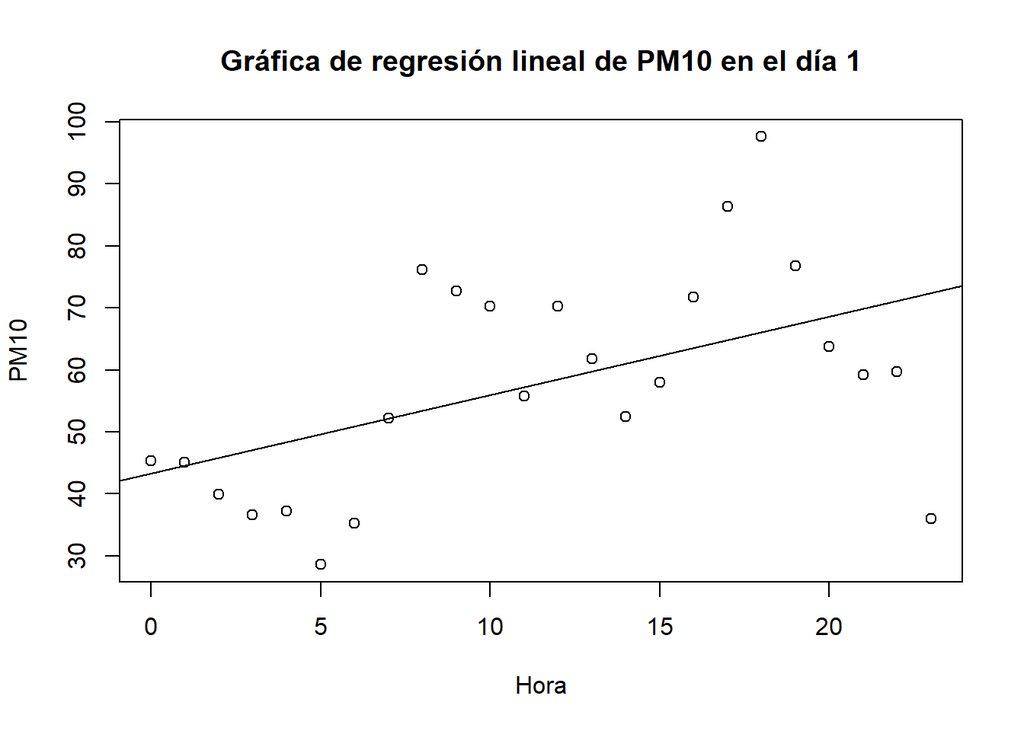

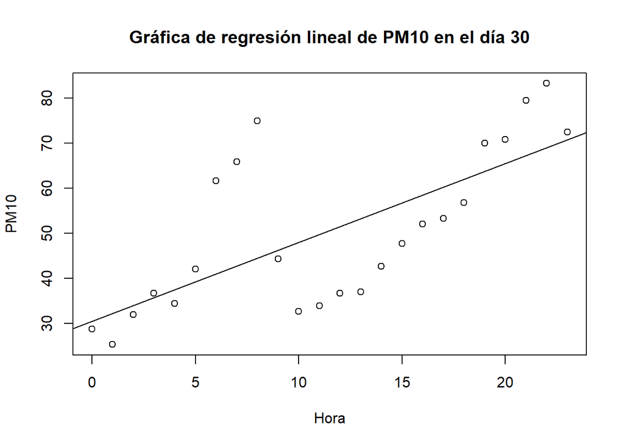

**Para la variable PM2.5:**

De nuevo emplearemos el cálculo y representación de la recta de mínimos cuadrados:

Análisis día 1:

```
##
## Call:
## lm(formula = dia1$`PM 2.5` ~ dia1$HORA, data = dia1)
##
## Residuals:
##     Min      1Q  Median      3Q     Max
## -7.4692 -4.2942  0.3364  2.6364 13.6997
##
## Coefficients:
##             Estimate Std. Error t value Pr(>|t|)
## (Intercept) 16.50033    2.03257   8.118 4.63e-08 ***
## dia1$HORA   -0.01778    0.15143  -0.117    0.908
## ---
## Signif. codes:  0 '***' 0.001 '**' 0.01 '*' 0.05 '.' 0.1 ' ' 1
##
## Residual standard error: 5.135 on 22 degrees of freedom
## Multiple R-squared:  0.0006264,  Adjusted R-squared:  -0.0448
## F-statistic: 0.01379 on 1 and 22 DF,  p-value: 0.9076
```

Los errores típicos de los estimadores de los parámetros β0 y β1 son: 2.03257 y 0.15143

El estimador de la desviación típica de los errores σ aparece como Residual standard error y su valor es 5.135

Los intervalos de confianza para los parámetros son los siguientes con un nivel de confianza del 95%:

```
##                  2.5 %     97.5 %
## (Intercept) 12.2850404 20.7156262
## dia1$HORA   -0.3318266  0.2962614
```

Analisis día 30:

```
##
## Call:
## lm(formula = dia30$`PM 2.5` ~ dia30$HORA, data = dia30)
##
## Residuals:
##    Min     1Q Median     3Q    Max
## -9.239 -4.811 -1.945  3.464 18.056
##
## Coefficients:
##             Estimate Std. Error t value Pr(>|t|)
## (Intercept)  14.3880     2.7234   5.283 2.66e-05 ***
## dia30$HORA    0.2195     0.2029   1.082    0.291
## ---
## Signif. codes:  0 '***' 0.001 '**' 0.01 '*' 0.05 '.' 0.1 ' ' 1
##
## Residual standard error: 6.88 on 22 degrees of freedom
## Multiple R-squared:  0.05052,    Adjusted R-squared:  0.007364
## F-statistic: 1.171 on 1 and 22 DF,  p-value: 0.291
```

Los errores típicos de los estimadores de los parámetros β0 y β1 son: 2.7234 y 0.2029

El estimador de la desviación típica de los errores σ aparece como Residual standard error y su valor es 6.88

El
$$r^2 = 0.05052$$

Los intervalos de confianza para los parámetros son los siguientes con un nivel de confianza del 95%:

```
##                  2.5 %     97.5 %
## (Intercept)  8.7401095 20.0358905
## dia30$HORA  -0.2012524  0.6402959
```

Para esta variable, las ecuaciones de la recta de mínimos cuadrados son:

Para el día 1:
$$PM2.5(t)=16.50033-0.01778t$$
Para el día 30:
$$PM2.5(t)=14.388+0.21951t$$

Donde el dominio y rango de las ecuaciones es:

Para ambas ecuaciones el dominio es:

$D =$ $t$ $ϵ$ $[0;24]$

Para el día 1:

$R =$ $PM2.5$ $ϵ$ $[8.8;30.2]$

Para el día 30:

$R =$ $PM2.5$ $ϵ$ $[5.6;34.2]$

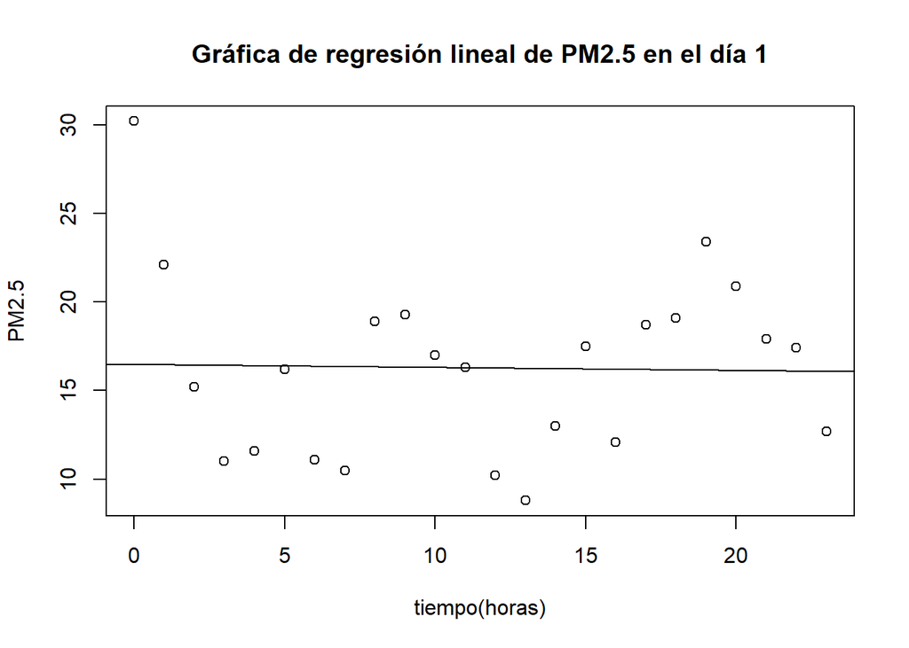

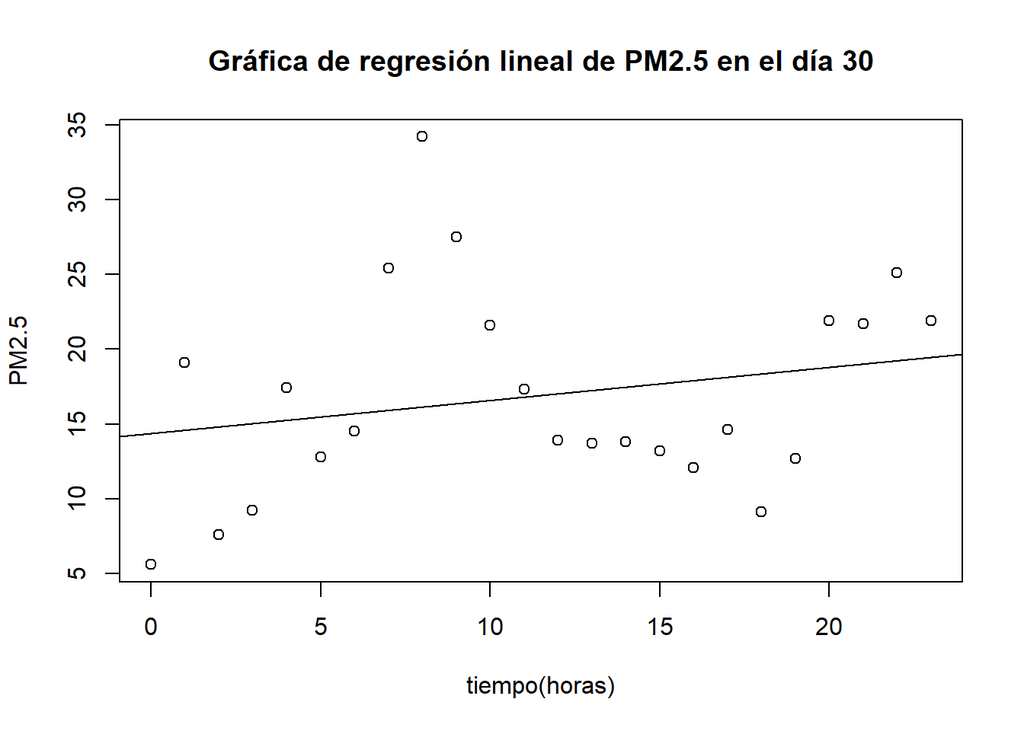

Los valores de coeficiente de determinación para la variable PM2.5 son: 0.0006264 y 0.05052 para el día 1 y 30, respectivamente.